# Downloading PDF files from DOIs

## Installing grobid

To install grobid, we first need to download the grobid docker image. Click on “Search Images to Run” in the middle of the screen and a new menu will open. In the search bar, type “grobid/grobid” and press enter. You should see a list of different grobid images. Select the one that says “grobid/grobid” (not grobid/grobid-crf) and click on “Pull”.

[figure not shown]

Docker Desktop

This process might take a while, as the image is about 18GB in size. Once the image is downloaded, you should see it in the list of images.

[figure not shown]

Docker Desktop

## Building our custom grobid image

### File endings

When I talk about a file like “build_grobid.bat” you might not see the “.bat” ending. This is because windows hides file endings by default. To see the file endings, you need to go to the “View” tab in the file explorer (View/Show on Windows 11) and check the box next to “File name extensions”.

The grobid image that we downloaded lacks some functionality that we need to easily work with it. Therefore, we need to build our own custom image, including some additional software. To do this, open the folder called “grobid_build” in the folder where you downloaded this document.

### Building custom grobid

Please run the next steps on your local computer, not on the onedrive folder.

Open the “docker_builder” folder and double click on build_grobid.bat The file will open a terminal window, running a script that will build our custom grobid image. After it is done, it will show “Press any key to continue . . .”, and on pressing any key on the keyboard, the window will close.

Now, if you go back to the docker desktop, you should see a new image called “grobid_pcurve”.

[figure not shown]

Docker Desktop

## Running grobid

Next you will be asked whether you want to run grobid recursively within this folder or not. Running grobid recursively means that each subfolder within the folder that you chose on startup will be processed and all the containing pdfs will be converted. If you want to run grobid on all the pdfs in the folder, enter “y” and press enter. If you only want to run grobid on the pdfs in the folder itself, enter “n” and press enter (see below).

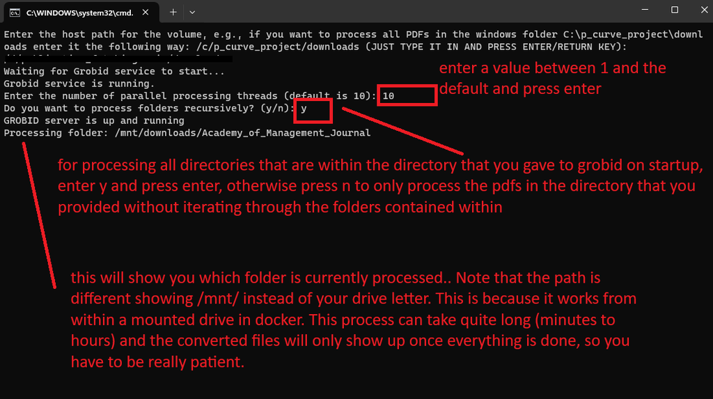

Conversion Process

The process can take really long and will only occasionally provide updates on what it is doing (once per folder if run recursively). Therefore, it might be wise to first try grobid on a test folder with few pdf files before running it on a large folder.

After grobid is done, you will see that the terminal got interactive again (i.e. you can type something in it). In your folder, you should now see the pdf files accompanied by a grobid.tei.xml file with the same name. At this point, the conversion is done and you can close the terminal window by entering “exit” and press enter. The docker container will shut down and disappear, and you need to restart it by double clicking on the “run_grobid.bat” file again (no need to run build_grobid.bat again).

## Finishing up

You can now copy the grobid.tei.xml files to the onedrive folder. Please copy the XML files only (i.e. not the pdfs) to the XMLs folder in the onedrive folder. Use the same structure as in the PDFs folder, i.e. create a subfolder for each journal and put the xml files in there.

## Troubleshooting

If you run into problems with grobid, try to run docker with only 1 thread instead of the suggested default.

If you have a powerful graphics card in your computer, you can try running the gpu_run_grobit.bat file instead of the run_grobid.bat file.